# Análisis de grafos y Redes Sociales. Hoja de ejercicios 1: Teoría de grafos

Javier Cano Montero

27 de febrero de 2017

# Análisis de Twitter.

El grafo out.ego-twitter almacena información acerca de usuarios de Twitter. En concreto, se trata de un grafo dirigido no ponderado donde cada vértice representa a un usuario, mientras que una arista (v, u) indica que el usuario v sigue al usuario u. El objetivo  
de esta hoja de ejercicios es analizar la estructura de este grafo y extraer diferentes características estructurales del mismo.

## 1. Carga del grafo en memoria.

Cargamos la librería **igraph** y leemos los datos del directorio **data**. A continuación convertimos la tabla de aristas en un grafo mediante la función **graph_from_data_frame**. Finalmente, como ya no necesitamos el data frame lo eliminamos para liberar memoria.

```r
library(igraph)
df <- read.table("/home/javier/practica_1_grafos/data/out.ego-twitter")
g <- graph_from_data_frame(df)
rm(df)
```

## 2. Mostrando el grafo.

El grafo se trata de una representación gráfica de la red social Twitter. El grafo representa cómo los usuarios se siguen entre ellos, por tanto, una arista del vértice **A** al vértice **B** representa que el usuario **A** sigue al **B**. Esta relación es unidireccional, ya que a diferencia de otras redes sociales, en Twitter **B** no está obligado a seguir a **A**. Por tanto este tipo de relación establece relaciones direccionales. Además las relaciones son únicas, un usuario sólo puede seguir una vez a otro usuario, por lo que no es necesario introducir pesos a las aristas.

Para mostrar el grafo y que sea mínimamente “visible” le modificaremos la estética de los vértices (tamaño, color,…) y las aristas (tamaño y tamaño de la flecha). También usaremos el layout DrL para organizar los vértices.

Viendo la representación del grafo, podemos confirmar que se trata de un grafo dirigido sin pesos no conexo.

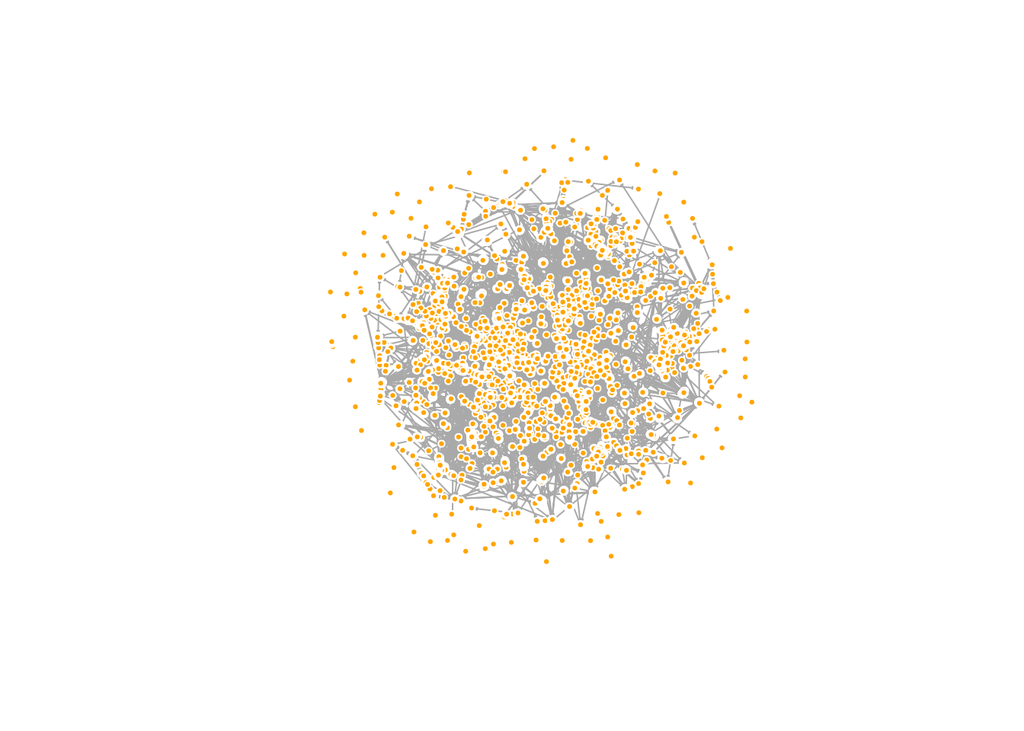

```r
V(g)$size <- 3
V(g)$frame.color <- "white"
V(g)$color <- "orange"
V(g)$label <- ""

E(g)$size <- 0.01
E(g)$arrow.mode <- 1
E(g)$arrow.size <- 0.1


l <- layout_with_drl(g, dim = 2)

plot(g, layout=l)
```

## 3. ¿Qué es el grado de un vértice en este grafo?

El grado de un vértice en un grafo sin pesos es el número de aristas que tiene ese vértice, tanto de entrada como de salida. Específicamente en este grafo esta medida representa el número de usuarios a los que un usuario sigue o le siguen.

Viendo la distribución de los grados en este grafo podemos ver que la gran mayoría de los usuarios tienen grado 1 y en media es de 2.833. También vemos que el grado máximo de un usuario es de 239.

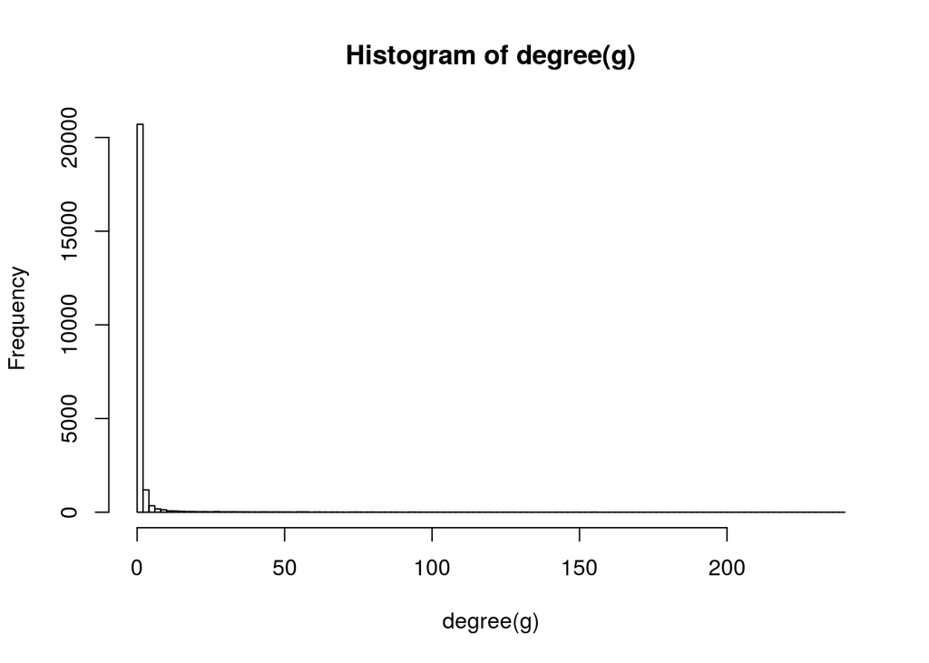

```r
hist(degree(g),breaks = 100)
```

```r
summary(degree(g))
```

```
##    Min. 1st Qu.  Median    Mean 3rd Qu.    Max.
##   1.000   1.000   1.000   2.833   1.000 239.000
```

## 4. Comunidad 190, 191, 192, 193, 194 y 13167

Esta comunidad no es fuertemente conexa porque no hay ninguna arista que tenga como objetivo al nodo 191. Sin embargo, sí que podemos decir que es una comunidad conexa.

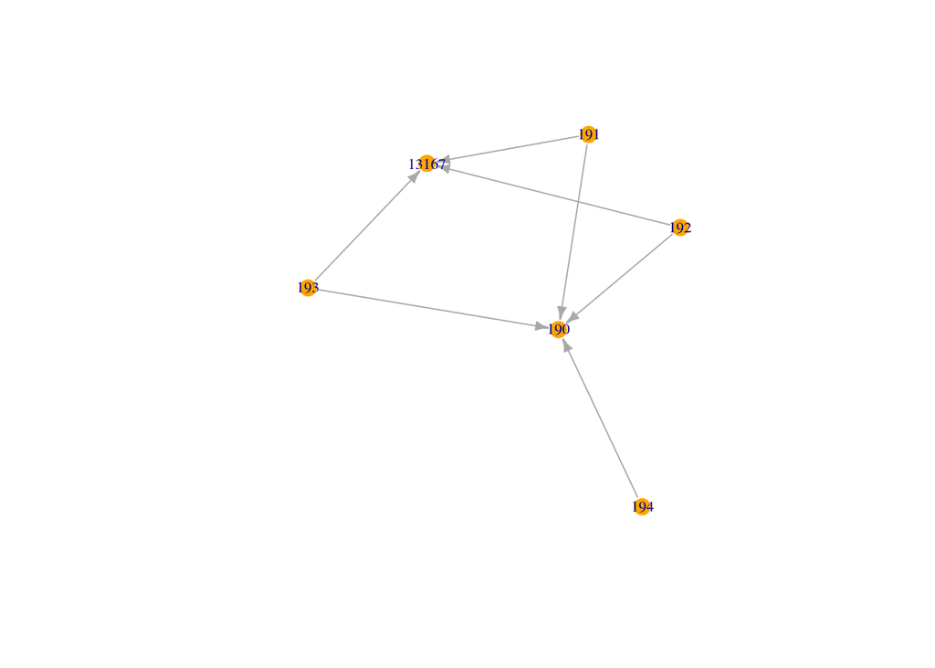

```r
E(g)$arrow.size <- 0.5
sg <- induced_subgraph(g, V(g)[which(V(g)$name %in% c("190","191","192","193","194","13167"))])

V(sg)$size <- 10
V(sg)$label=V(sg)$name
V(sg)$label.cex=0.7

plot(sg)
```

## 5. ¿Quién tiene más seguidores?¿Quién sigue a más personas?

```r
# Max followers
which.max(degree(g, mode="in"))
```

```
##  36
## 708
```

```r
# Max following
which.max(degree(g, mode="out"))
```

```
## 11824
##   398
```

## 6. ¿Quién sigue a 1305?

Con la lista de adyacencias podemos estudiar qué nodos tienen aristas entrantes al vértice 1305. Se muestran a continuación:

```r
adjacent_vertices(g,V(g)[V(g)$name=="1305"],mode="in")
```

```
## $`1305`
## + 4/23370 vertices, named:
## [1] 1301  7331  13200 16843
```

## 7. ¿A quién sigue 1373?

Del mismo modo podemos estudiar cuáles son los nodos objetivo de las aristas salientes del vértice 1373. Se muestran a continuación:

```r
adjacent_vertices(g,V(g)[V(g)$name=="1373"],mode="out")
```

```
## $`1373`
## + 57/23370 vertices, named:
##  [1] 537   2050  8968  5289  16332 501   920   1872  1880  2048  2051
## [12] 2055  2089  2092  3687  3816  6279  6280  6281  6291  6292  6294
## [23] 6297  6303  6304  6305  6307  6312  6319  6320  6321  6322  6325
## [34] 10635 16309 16310 16311 16312 16313 16314 16315 16316 16317 16318
## [45] 16319 16320 16321 16322 16323 16324 16325 16326 16327 16328 16329
## [56] 16330 16331
```

## 8. ¿Cuál es el ratio de seguidores/siguiendo de 13815?

Para calcular el ratio basta con calcular el número de aristas entrantes/aristas salientes.

```r
id <- V(g)[V(g)$name=="13815"]
length(adjacent_vertices(g,id,mode="in")[[1]])/length(adjacent_vertices(g,id,mode="out")[[1]])
```

```
## [1] 0.1111111
```

Dado que este ratio es menor que 1, quiere decir que tiene más aristas saliente que entrantes (sigue a más usuarios que usuarios le siguen a él), por lo que podemos afirmar que es un usuario poco influyente.

## 9. ¿Es el grafo una gran comunidad?

Como hemos visto en el segundo punto, el grafo no es conexo, por lo que forma distintas comunidades.

```r
# Comprobamos si es conexo.
is.connected(g)
```

```
## [1] FALSE
```

Para calcular las comunidades usaremos el clustering infomap[http://igraph.org/r/doc/cluster_infomap.html].

```r
# Calculamos las comunidades con infomap e imprimimos las comunidades por pantalla.
cl <- cluster_infomap(g)
print(sizes(cl))
```

```
## Community sizes
##     1     2     3     4     5     6     7     8     9    10    11    12
## 22283    74    52    40    35    34    33    31    31    30    30    28
##    13    14    15    16    17    18    19    20    21    22    23    24
##    28    27    26    24    22    21    20    17    18    17    15    15
##    25    26    27    28    29    30    31    32    33    34    35    36
##    15    15    14    14    14    14    14    13    12    12    12    10
##    37    38    39    40    41    42    43    44    45    46    47    48
##    11    11    10    10    10    10     9     9     9     8     8     7
##    49    50    51    52    53    54    55    56    57    58    59    60
##     7     7     6     6     6     6     6     3     5     5     5     5
##    61    62    63    64    65    66    67    68    69    70    71    72
##     4     4     4     3     3     3     3     3     2     2     2     2
##    73    74    75    76    77    78    79    80    81    82    83    84
##     2     2     2     2     2     2     2     2     2     2     2     2
##    85    86    87    88    89    90    91    92    93    94    95
##     2     2     2     2     2     2     2     2     2     2     2
```

## 10. Estudiando la comunidad de 35 usuarios.

Para estudiar la comunidad de 35 usuarios, primero buscaremos el identificador dado por el algoritmo de clustering y calcularemos su subgrafo.

```r
id_com <- which(sizes(cl)==35)
sg <- induced_subgraph(g,V(g)[cl$membership==id_com])
degree(sg)
```

```
## 1445 1446 1447 1448 1449 1450 1451 1452 1453 1454 1455 1456 1457 1458 1459
##   34    1    1    1    1    1    1    1    1    1    1    1    1    1    1
## 1460 1461 1462 1463 1464 1465 1466 1467 1468 1469 1470 1471 1472 1473 1474
##    1    1    1    1    1    1    1    1    1    1    1    1    1    1    1
## 1475 1476 1477 1478 1479
##    1    1    1    1    1
```

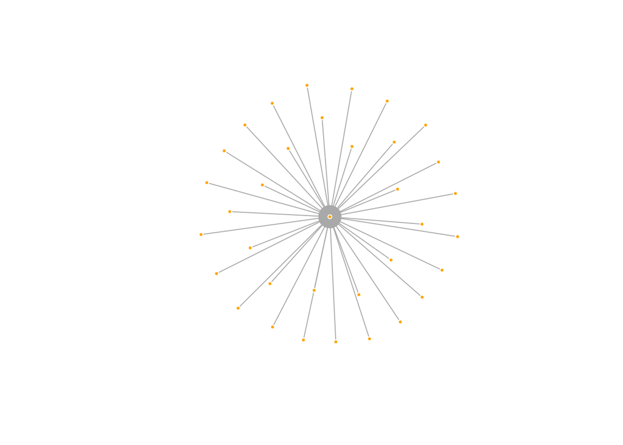

```r
plot(sg)
```

Como se puede ver en la representación y en el estudio de los grados del subgrafo, el usuario 1445 es el más importante de esta comunidad con grado 34 y el resto de usuarios sólo tienen una conexión con este usuario.

## 11. Estudiando la comunidad más grande.

Como hemos hecho en el paso anterior, primero procederemos a identificar qué comunidad es la más grande de las obtenidas por el algoritmo de clustering y calcularemos su subgrafo.

```r
id_max <- which.max(sizes(cl))
sg <- induced_subgraph(g,V(g)[cl$membership==id_max])
```

```r
which.max(closeness(sg))
```

```
## 7045
##  215
```

```r
which.max(betweenness(sg))
```

```
## 1368
##  787
```

# Conclusiones.

Se ha realizado un estudio de un subconjunto de usuarios de Twitter y cómo se relacionan entre ellos usando únicamente la acción **seguir**. Se ha estudiado con la librería **igraph** cómo cargar un grafo desde un csv, el significado de distintas medidas de centralidad y cómo extraer subgrafos.